# RNA-Seq of pathogen inoculated arabidopsis with batch effects

# 1.Introduction

This file is adapted from the edgeR userguide. Note, that the current version of the edgeR userguide is adopting the quasi-likelihood pipeline in edgeR. We will use the conventional likelihood based pipeline.

You can open the userguide by:

```
edgeRUsersGuide()
```

This case study re-analyses Arabidopsis thaliana RNA-Seq data described by Cumbie et al. Summarized count data is available as a data object in the CRAN package NBPSeq comparing $\Delta$hrcC challenged and mock-inoculated samples. Samples were collected in three batches, and adjustment for batch effects proves to be important. The aim of the analysis therefore is to detect genes differentially expressed in response to $\Delta$hrcC challenge, while correcting for any differences between the batches.

# 2. RNA samples

Pseudomonas syringae is a bacterium often used to study plant reactions to pathogens. In this experiment, six-week old Arabidopsis plants were inoculated with the $\Delta$hrcC mutant of P. syringae, after which total RNA was extracted from leaves. Control plants were inoculated with a mock pathogen. Three biological replicates of the experiment were conducted at separate times and using independently grown plants and bacteria. The six RNA samples were sequenced one per lane on an Illumina Genome Analyzer. Reads were aligned and summarized per gene using GENE-counter. The reference genome was derived from the TAIR9 genome release (www.arabidopsis.org).

# 3. Loading the data

Load the data:

```r
library(NBPSeq)
data(arab)
head(arab)
```

```
          mock1 mock2 mock3 hrcc1 hrcc2
AT1G01010    35    77    40    46    64
AT1G01020    43    45    32    43    39
AT1G01030    16    24    26    27    35
AT1G01040    72    43    64    66    25
AT1G01050    49    78    90    67    45
AT1G01060     0    15     2     0    21
          hrcc3
AT1G01010    60
AT1G01020    49
AT1G01030    20
AT1G01040    90
AT1G01050    60
AT1G01060     8
```

There are two experimental factors, treatment (hrcc vs mock) and the time that each replicate was conducted. We relevel the treatments so that the mock treatment becomes the reference class.

```r
treat <- factor(substring(colnames(arab),1,4))
treat <- relevel(treat, ref="mock")
time <- factor(substring(colnames(arab),5,5))
```

We then create a DGEList object:

```r
y <- DGEList(counts=arab, group=treat)
y$sample
```

```
      group lib.size norm.factors
mock1  mock  1902162            1
mock2  mock  1934131            1
mock3  mock  3259861            1
hrcc1  hrcc  2130030            1
hrcc2  hrcc  1295377            1
hrcc3  hrcc  3526743            1
```

# 4. Filtering and normalization

There is no purpose in analysing genes that are not expressed in either experimental condi- tion. We consider a gene to be expressed at a reasonable level in a sample if it has at least two counts for each million mapped reads in that sample. This cutoff is ad hoc, but serves to require at least 4-6 reads in this case. Since this experiment has three replicates for each condition, a gene should be expressed in at least three samples if it responds to at least one condition. Hence we keep genes with at least two counts per million (CPM) in at least three samples:

```r
 keep <- rowSums(cpm(y)>2) >= 3
 table(keep)
```

```
keep
FALSE  TRUE
 9696 16526
```

```r
 y <- y[keep, , keep.lib.sizes=FALSE]
```

Note that the filtering does not use knowledge of what treatment corresponds to each sample, so the filtering does not bias the subsequent differential expression analysis. The TMM normalization is applied to account for the compositional biases:

```r
y <- calcNormFactors(y)
y$samples
```

```
      group lib.size norm.factors
mock1  mock  1896802    0.9788858
mock2  mock  1898690    1.0536314
mock3  mock  3249396    0.9032971
hrcc1  hrcc  2119367    1.0507312
hrcc2  hrcc  1264927    1.0957058
hrcc3  hrcc  3516253    0.9323158
```

# 5. Data exploration

An MDS plot shows the relative similarities of the six samples.

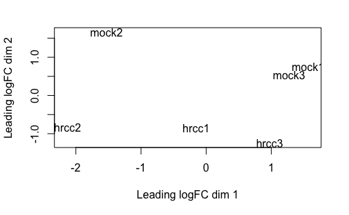

```r
plotMDS(y)
```

Distances on an MDS plot of a DGEList object correspond to leading log-fold-change between each pair of samples. Leading log-fold-change is the root-mean-square average of the largest log2-fold-changes between each pair of samples. Each pair of samples extracted at each time tend to cluster together, suggesting a batch effect. The hrcc treated samples tend to be below the mock samples for each time, suggesting a treatment effect within each time. The two samples at time 1 are less consistent than at times 2 and 3.

# 6. The design matrix

Before we fit GLMs, we need to define our design matrix based on the experimental design. We want to test for differential expressions between $\Delta$hrcC challenged and mock-inoculated samples within batches, i.e. adjusting for differences between batches. In statistical terms, this is an additive linear model. So the design matrix is created as:

```r
design <- model.matrix(~time+treat)
rownames(design) <- colnames(y)
design
```

```
      (Intercept) time2 time3 treathrcc
mock1           1     0     0         0
mock2           1     1     0         0
mock3           1     0     1         0
hrcc1           1     0     0         1
hrcc2           1     1     0         1
hrcc3           1     0     1         1
attr(,"assign")
[1] 0 1 1 2
attr(,"contrasts")
attr(,"contrasts")$time
[1] "contr.treatment"

attr(,"contrasts")$treat
[1] "contr.treatment"
```

# 7. Estimating the dispersion

Estimate the genewise dispersion estimates over all genes, allowing for a possible abundance trend. The estimation is also robustified against potential outlier genes.

```r
y <- estimateDisp(y, design, robust=TRUE)
y$common.dispersion
```

```
[1] 0.07051334
```

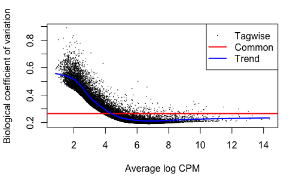

```r
plotBCV(y)
```

The square root of dispersion is the coefficient of biological variation (BCV). The common BCV is on the high side, considering that this is a designed experiment using genetically identical plants. The trended dispersion shows a decreasing trend with expression level. At low logCPM, the dispersions are very large indeed.

# Differential expression

## Fit model and Goodness of Fit test

Now we test for significant differential expression in each gene.

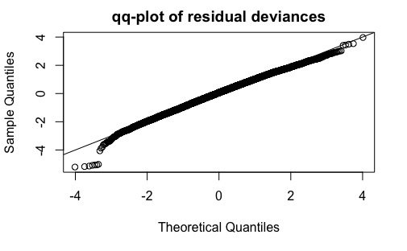

```r
fit <- glmFit(y,design)
gof(fit,plot=TRUE)
```

As usual when using statistical models, we would like to know how well our selected model fits the data. We can assess the goodness of our NB GLM with a given dispersion value computing the deviance statistics and comparing them to a chi-square distribution. We can visually assess the goodness of fit using quantile-quantile plots. Here the deviance goodness-of-fit statistics (chi-square distributed) is transformed to normality and a normal QQ-plot is produced for the NB GLMs using common and tagwise dispersions. These QQ-plots show only deviations to smaller values than expected. These indicates no lack of fit. We have lack of fit if the sample quantiles are larger than the theoretical quantiles. The statistics with deviations to smaller values might be an indication for overfitting.

## Check for batch effect

First we check whether there was a genuine need to adjust for the experimental times. We do this by testing for differential expression between the three times. There is considerable differential expression, justifying our decision to adjust for the batch effect.

```r
batch <- glmLRT(fit, coef=2:3)
topTags(batch)
```

```
Coefficient:  time2 time3
          logFC.time2 logFC.time3
AT5G66800    5.577158  -1.0647931
AT5G31702    5.828726  -2.5673366
AT5G23000    5.596868  -0.2899055
AT3G33004    4.813272  -1.7570022
AT2G45830    5.418033  -0.5889821
AT2G08986    7.215838  -0.6033378
AT2G11230    3.497498  -1.5289336
AT5G35736    5.396603  -0.9986563
AT2G07782    3.483669  -1.6148497
AT2G18193    3.054719  -2.3958126
            logCPM       LR
AT5G66800 5.483508 273.2852
AT5G31702 5.952235 234.9069
AT5G23000 5.708318 232.2158
AT3G33004 5.627532 225.8769
AT2G45830 4.706108 190.4000
AT2G08986 6.813791 182.1861
AT2G11230 5.599229 171.0784
AT5G35736 4.604976 164.7415
AT2G07782 5.277395 161.8854
AT2G18193 5.078476 146.9966
                PValue          FDR
AT5G66800 4.538083e-60 7.499635e-56
AT5G31702 9.785996e-52 8.086169e-48
AT5G23000 3.758270e-51 2.070306e-47
AT3G33004 8.942480e-50 3.694586e-46
AT2G45830 4.520267e-42 1.494039e-38
AT2G08986 2.746568e-40 7.564963e-37
AT2G11230 7.092502e-38 1.674438e-34
AT5G35736 1.685913e-36 3.482674e-33
AT2G07782 7.031140e-36 1.291073e-32
AT2G18193 1.202502e-32 1.987255e-29
```

```r
FDR=p.adjust(batch$table$PValue,method="BH")
sum(FDR<0.05)
```

```
[1] 3292
```

Now conduct tests for the pathogen effect and show the top genes. By default, the test is for the last coefficient in the design matrix, which in this case is the treatment effect:

```r
pathogen <- glmLRT(fit)
topTags(pathogen)
```

```
Coefficient:  treathrcc
             logFC   logCPM       LR
AT5G48430 6.326182 6.729025 251.4971
AT2G19190 4.497837 7.373501 229.5956
AT3G46280 4.782743 8.096900 209.2322
AT2G39530 4.339349 6.709049 204.6774
AT2G39380 4.941307 5.771324 186.6835
AT1G51800 3.967388 7.709689 186.2396
AT1G51850 5.320543 5.418659 170.0298
AT5G64120 3.711337 9.696155 167.7561
AT1G51820 4.335824 6.373316 165.8623
AT2G44370 5.414643 5.199481 163.8767
                PValue          FDR
AT5G48430 1.224799e-56 2.024103e-52
AT2G19190 7.303726e-52 6.035069e-48
AT3G46280 2.020122e-47 1.112818e-43
AT2G39530 1.991486e-46 8.227823e-43
AT2G39380 1.683792e-42 5.565268e-39
AT1G51800 2.104725e-42 5.797113e-39
AT1G51850 7.288721e-39 1.720763e-35
AT5G64120 2.287050e-38 4.724473e-35
AT1G51820 5.928643e-38 1.088631e-34
AT2G44370 1.609523e-37 2.659897e-34
```

Here’s a closer look at the individual counts-per-million for the top genes. The top genes are very consistent across the three replicates:

```r
top <- rownames(topTags(pathogen))
cpm(y)[top,]
```

```
               mock1       mock2
AT5G48430   4.308598   4.4988315
AT2G19190  16.695817  11.9968839
AT3G46280  18.850116  16.9955856
AT2G39530   7.001472   8.9976629
AT2G39380   2.154299   2.9992210
AT1G51800  29.083037  16.4957154
AT1G51850   1.077150   0.9997403
AT5G64120 134.105113 114.4702675
AT1G51820   9.694346   7.4980525
AT2G44370   2.154299   0.9997403
               mock3      hrcc1
AT5G48430   0.000000  189.05332
AT2G19190  13.287134  341.28391
AT3G46280  18.397571  384.84251
AT2G39530  13.287134  158.06834
AT2G39380   4.769741   91.60779
AT1G51800  30.662618  362.38962
AT1G51850   3.747653   78.13605
AT5G64120 104.593596 1340.88651
AT1G51820   6.132524  121.24560
AT2G44370   1.703479   57.03034
               hrcc2      hrcc3
AT5G48430  314.57707  125.06641
AT2G19190  254.69198  351.10108
AT3G46280  374.46215  820.86272
AT2G39530  191.92087  243.11690
AT2G39380   84.41632  135.13273
AT1G51800  347.76639  463.96589
AT1G51850   56.27755  108.89929
AT5G64120 1644.31454 1635.01456
AT1G51820  156.56703  191.26010
AT2G44370   67.10015   86.02129
```

The total number of genes significantly up-regulated or down-regulated at 5% FDR is summarized as follows:

```r
summary(dt <- decideTestsDGE(pathogen))
```

```
       treathrcc
Down        1245
NotSig     14033
Up          1248
```

## Plots

We can pick out which genes are DE:

```r
isDE <- as.logical(dt)
DEnames <- rownames(y)[isDE]
```

### MA-plot

Then we can plot all the logFCs against average count size, highlighting the DE genes:

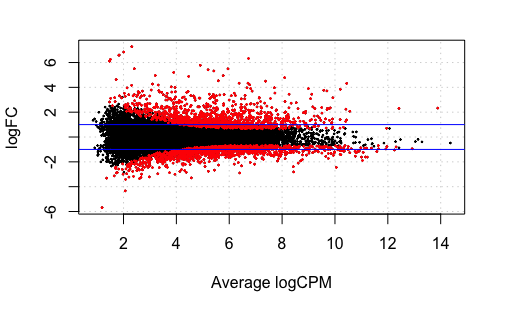

```r
plotSmear(pathogen, de.tags=DEnames)
abline(h=c(-1,1), col="blue")
```

### Volcanoplot

Note, that the parameters of the models are still in the natural log. So the fold changes are equal to: parameter*log2(exp(1))

```r
pathogen$coefficients[top,]
```

```
          (Intercept)       time2
AT5G48430  -12.819263  0.40725148
AT2G19190  -11.062184 -0.30761249
AT3G46280  -11.052197 -0.05993737
AT2G39530  -11.787155  0.20665072
AT2G39380  -12.768623 -0.01462807
AT1G51800  -10.572800 -0.24873130
AT1G51850  -13.205085 -0.30066318
AT5G64120   -9.048505  0.02249481
AT1G51820  -11.855334  0.07993181
AT2G44370  -13.449414  0.04112162
                time3 treathrcc
AT5G48430 -0.70760784  4.384975
AT2G19190 -0.06702969  3.117663
AT3G46280  0.44704763  3.315145
AT2G39530  0.49868359  3.007808
AT2G39380  0.46125642  3.425053
AT1G51800  0.16292230  2.749984
AT1G51850  0.48363524  3.687919
AT5G64120 -0.02181892  2.572503
AT1G51820  0.15547379  3.005364
AT2G44370  0.31073545  3.753145
```

```r
topTags(pathogen)
```

```
Coefficient:  treathrcc
             logFC   logCPM       LR
AT5G48430 6.326182 6.729025 251.4971
AT2G19190 4.497837 7.373501 229.5956
AT3G46280 4.782743 8.096900 209.2322
AT2G39530 4.339349 6.709049 204.6774
AT2G39380 4.941307 5.771324 186.6835
AT1G51800 3.967388 7.709689 186.2396
AT1G51850 5.320543 5.418659 170.0298
AT5G64120 3.711337 9.696155 167.7561
AT1G51820 4.335824 6.373316 165.8623
AT2G44370 5.414643 5.199481 163.8767
                PValue          FDR
AT5G48430 1.224799e-56 2.024103e-52
AT2G19190 7.303726e-52 6.035069e-48
AT3G46280 2.020122e-47 1.112818e-43
AT2G39530 1.991486e-46 8.227823e-43
AT2G39380 1.683792e-42 5.565268e-39
AT1G51800 2.104725e-42 5.797113e-39
AT1G51850 7.288721e-39 1.720763e-35
AT5G64120 2.287050e-38 4.724473e-35
AT1G51820 5.928643e-38 1.088631e-34
AT2G44370 1.609523e-37 2.659897e-34
```

```r
pathogen$coefficients[top,]*log2(exp(1))
```

```
          (Intercept)       time2
AT5G48430   -18.49429  0.58753969
AT2G19190   -15.95936 -0.44379101
AT3G46280   -15.94495 -0.08647135
AT2G39530   -17.00527  0.29813396
AT2G39380   -18.42123 -0.02110385
AT1G51800   -15.25333 -0.35884341
AT1G51850   -19.05091 -0.43376528
AT5G64120   -13.05423  0.03245315
AT1G51820   -17.10363  0.11531723
AT2G44370   -19.40340  0.05932595
                time3 treathrcc
AT5G48430 -1.02086232  6.326182
AT2G19190 -0.09670339  4.497837
AT3G46280  0.64495340  4.782743
AT2G39530  0.71944835  4.339349
AT2G39380  0.66545235  4.941307
AT1G51800  0.23504720  3.967388
AT1G51850  0.69773816  5.320543
AT5G64120 -0.03147804  3.711337
AT1G51820  0.22430126  4.335824
AT2G44370  0.44829649  5.414643
```

```r
plot(pathogen$coefficients[,"treathrcc"]*log2(exp(1)),-log10(pathogen$table$PValue),pch=19,cex=.2,xlab=expression(paste(log[2],"(FC)",sep="")),ylab=expression(paste("-",log[10],"(p)",sep="")))
points(pathogen$coefficients[DEnames,"treathrcc"]*log2(exp(1)),-log10(pathogen$table[DEnames,"PValue"]),col=2)
```

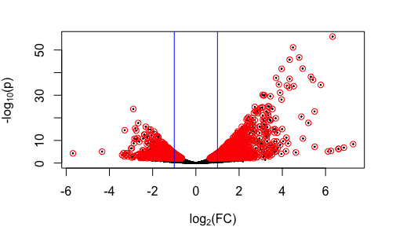

```r
abline(v=c(-1,1), col="blue")
```